# How Is a Nespresso Capsule Possible?

Stephen Weymouth

Dean’s Professor

2026-08-26

# Welcome to International Business!

## I Teach and Write about Globalization

[figure not shown]

- Joined Georgetown faculty in 2010
- Director, Global Business Fellows Program
- Co-Director, Master in Intl Business and Policy
- Expertise in how globalization impacts firms, governments, and individuals
- Special Sworn Employee, US Bureau of Economic Analysis (2012–2022)

# A Brief Writing Exercise

## Ideas and skills that are uniquely your own

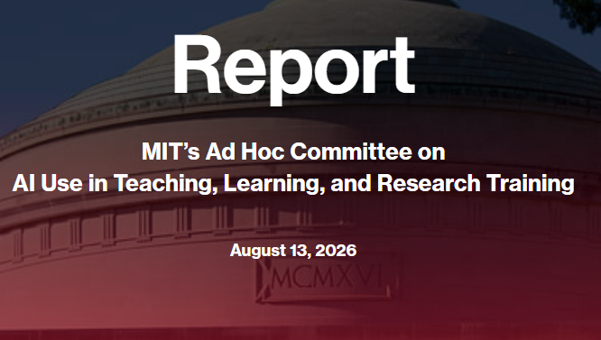

Goldstein, describing a student

“If she wanted to be valuable on the job market, she felt, she would need to have ideas and skills that were uniquely her own.”

MIT report

“the most important product of their education is not a GPA or a diploma but themselves … the development of their own imagination, insight, and judgment.”

Writing first gives you a perspective of your own to test, defend, and revise.

## Your IB Voice

Question

How is a Nespresso capsule possible? Explain what must be coordinated for this product to reach a consumer.

**12 minutes** · Individual · Blue book · Ungraded

I will collect your response and return it for you to critique during the final exam.

## No one knows how to make the whole pencil?

No participant possesses all the knowledge required to make it. The logger, miner, chemist, machinist, and executive each know only part(s) of the process.

Why do they participate?

If no one directs the entire system, how does a pencil get made?

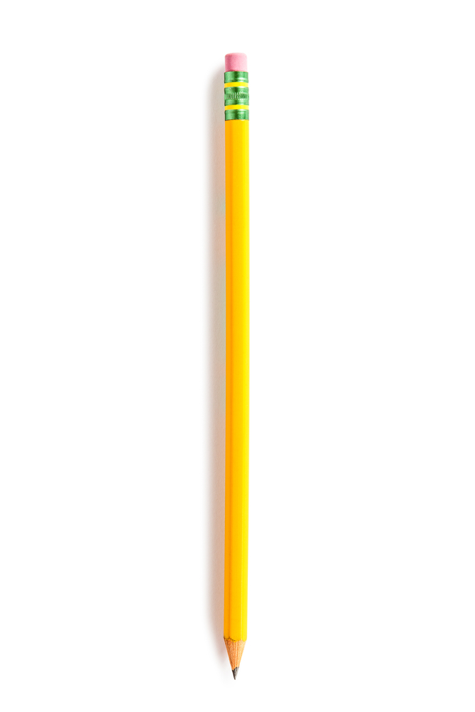

## A powerful (yet incomplete) story

### What Read covers

- Dispersed knowledge
- Specialization and exchange
- Markets and invisible hands
- Coordination without a central planner

### What Read does not cover

- Firms, locations, and contracts
- Standards, finance, and infrastructure
- Governments, policies, and borders
- Dependence, power, and disruption

## Reconstruct the system

What must happen before a Nespresso capsule reaches a consumer?

10 mins. Working in small groups, identify the actors, activities, inputs, places, and relationships you think are necessary.

Focus on what you can infer without additional research. Note what you would need more time to investigate.

## Production inputs and supply chains

[figure not shown]

- **Coffee supply:** farms, mills, and exporters
- **Capsule supply:** aluminum body and seal, coating, and filters
- **Package supply:** boxing, printing and adhesives
- **Factory:** machinery, energy, and quality control
- **Production:** roast, blend, grind, fill, seal, and pack
- **Distribution:** cases, pallets, transport, customs, warehousing, and delivery

## One product contains three different problems

### Market

How do prices incentivize specialized producers who do not know one another to coordinate?

### Firm

What should Nestlé own, contract for (outsource), and locate in which countries?

### State

What will governments and societies permit, require, or prevent? What causes the rules to change?

International business involves the interaction of all three.

## Knowledge requires open exchange

Yale Committee on Trust in Higher Education

Free speech as a first principle. “Colleges and universities have a special obligation to protect the classroom as a distinct place, where open exchange and structured conversation can thrive.”

MIT report

“every subject should include a regular in-person social component”

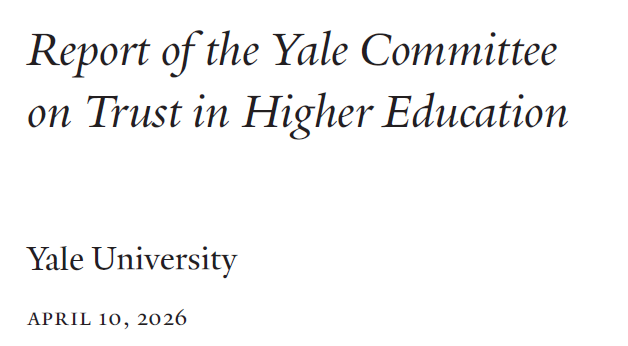

Freedom of expression is a first principle in this classroom. We will test ideas openly and solve problems together.

## How this course will work

Puzzle → individual writing → discussion → concept(s) → application → reflection

- Complete the assigned reading before class.
- Begin with your own written position.
- Put devices away after the opening response.
- Use LLMs when permitted.

Assessment combines contribution, an in-class midterm, an industry project, and a cumulative final exam.

## The course begins where “I, Pencil” ends

How is cross-border business organized, and what makes the arrangements sustainable or vulnerable?